# Working with logistic regression models

Mark Scheuerell

15 May 2026

# Background

These lab exercises focus on fitting and evaluating generalized linear models (GLMs). We’ll use the examples we saw in lecture to demonstrate the various options in **R** for fitting models, evaluating their goodness-of-fit, and examining model diagnostics. In particular, we’ll focus on logistic regression for binary data and Poisson regression for count data.

## Components of a GLM

As we saw in lecture, there are 3 important components to a GLM:

1. Distribution of the data: $y \sim f_{\theta}(y)$
2. Link function: $g(\eta)$
3. Linear predictor: $\eta = \mathbf{X} \boldsymbol{\beta}$

We are interested in the so-called *canonical links* for GLMs. Here is a summary table of the canonical links, and their mean functions, for three common distributions.

| Distribution | Link name | Link function | Mean function |
| --- | --- | --- | --- |
| Normal | Identity | $1(\mu) = \mathbf{X} \boldsymbol{\beta}$ | $\mu = \mathbf{X} \boldsymbol{\beta}$ |
| Binomial | Logit | $\log \left( \frac{\mu}{1 - \mu} \right) = \mathbf{X} \boldsymbol{\beta}$ | $\mu = \frac{\exp (\mathbf{X} \boldsymbol{\beta})}{1 + \exp (\mathbf{X} \boldsymbol{\beta})}$ |
| Poisson | Log | $\log (\mu) = \mathbf{X} \boldsymbol{\beta}$ | $\mu = \exp (\mathbf{X} \boldsymbol{\beta})$ |

# Logistic regression

Logistic regression is used to model data consisting of binary (0/1) outcomes. The basis for these models is the binomial distribution, which has a probability mass function given by

$$\Pr(k; n, p) = \left( \begin{array}{c} n \\ k \end{array} \right) p^k (1
- p)^{n - k} \\
~ \\
\left( \begin{array}{c} n \\ k \end{array} \right) = \frac{n!}{k!(n -
k)!}$$

When we have individual-level information on presence/absence, alive/dead, mature/immature, etc, the binomial is reduced to the special case where $n = 1$. Specifically, this is known as the Bernoulli distribution, where

$$\Pr(k; n, p) = \left( \begin{array}{c} n \\ k \end{array} \right) p^k (1
- p)^{n - k} \\
\Downarrow \\
\Pr(k; p) = p^k (1 - p)^{(1 - k)} \\
\Downarrow \\
k = \left\{ \begin{array}{l} 1 ~ \text{if success (T, Y) with
probability }p \\ 0 ~ \text{if failure (F, N) with probability }(1 - p)
\end{array} \right.$$

The mean and variance of the Bernoulli distribution are given by

$$\text{Mean}(k) = p \\
\text{Var}(k) = p(1 - p)$$

## Model components

The three components of a logistic regression model are

$$\begin{aligned}
\text{data distribution:} & ~~ y_i \sim \text{Bernoulli}(p_i) \\ \\
\text{link function:} & ~~ \text{logit}(p_i) =
\text{log}\left(\frac{p_i}{1-p_i}\right) = \eta_i \\ \\
\text{linear predictor:} & ~~ \eta_i = \mathbf{X} \boldsymbol{\beta}
\end{aligned}$$

## Model for smolt age

Sockeye salmon are born in freshwater and rear there for some time before migrating to the ocean as *smolts*. The age at which sockeye smolt can vary from 1 to 2 years, which is thought to depend on their body size. Let’s examine the relationship between fish length and its probability of smolting at age-2 instead of age-1. Here are the data we saw in lecture.

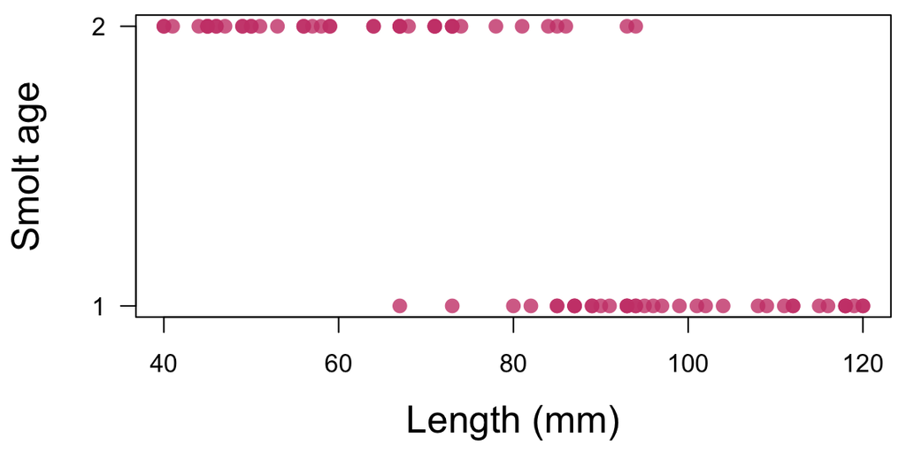

```r
set.seed(514)
## sample size
nn <- 80
## intercept
b0 <- 16
## slope
b1 <- -0.2
## lengths
sl <- seq(40, 120)
ll <- sample(sl, nn, replace = TRUE)
## probability as function of length
pp <- 1 / (1 + exp(-(b0 + b1*ll)))
## sim smolt age {0,1}
yy <- rep(NA, nn)
for(i in 1:nn) {
  yy[i] <- rbinom(1, 1, pp[i])
}

## make data frame for model fitting
df <- data.frame(length = ll, age = yy)

clr <- viridis::plasma(1, 0.8, 0.5, 0.5)
## set plot area
par(mai = c(0.9, 0.9, 0.1, 0.1),
    omi = c(0, 0, 0, 0),
    cex.lab = 1.5)
## plot age v
plot(ll, yy, las = 1, pch = 16, cex = 1.3, col = clr,
     yaxt = "n", ylab = "Smolt age", xlab = "Length (mm)")
axis(2, at = c(0,1), labels = c(1,2), las = 1)
```

### Fitting the model

In **R** we use `glm()` to fit logistic regression models. To do so, we need to specify the three components of a GLM. As with regular linear models, we specify the linear predictors as `~ predictors`. The distribution is given by the argument `family = distribution` and the link is specified parenthetically within the distribution name `family = distribution(link = "link_name")`. Here is our model for smolt age as a function of length using a binomial distribution with a logit link.

```r
## fit model with glm
fit_mod <- glm(age ~ length, data = df,
               family = binomial(link = "logit"))
faraway::sumary(fit_mod)
```

```
##              Estimate Std. Error z value  Pr(>|z|)
## (Intercept) 14.216166   3.417816  4.1594 3.190e-05
## length      -0.173990   0.041051 -4.2383 2.252e-05
##
## n = 80 p = 2
## Deviance = 39.91950 Null Deviance = 110.70347 (Difference = 70.78396)
```

The probability of a “success” (i.e., a smolt of age-2) is given by

$$\begin{align}
p &= \frac{\exp(\mathbf{X} \boldsymbol{\beta})}{1 + \exp(\mathbf{X}
\boldsymbol{\beta})} \\
~ \\
&= \frac{1}{1 + \exp(\text{-} \mathbf{X} \boldsymbol{\beta})}
\end{align}$$

We can get the fitted values *on the scale of the linear predictor* with `predict()` and overlay the fit on the data.

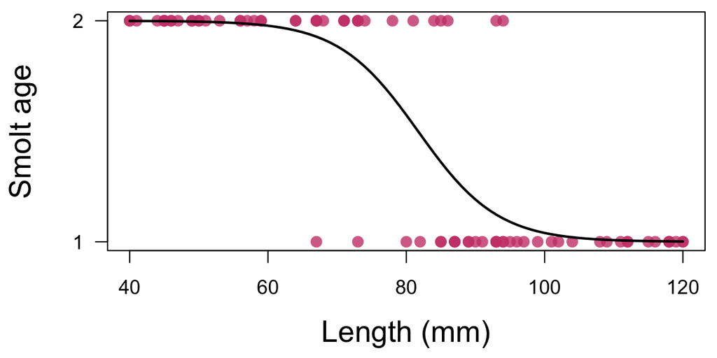

```r
## get fitted values
newdata <- data.frame(length = seq(40, 120))
eta <- predict(fit_mod, newdata)
p_hat <- 1 / (1 + exp(-eta))

## set plot area
par(mai = c(0.9, 0.9, 0.1, 0.1),
    omi = c(0, 0, 0, 0),
    cex.lab = 1.5)

## plot age vs length
plot(ll, yy, pch = 16, cex = 1.3, col = clr,
     yaxt = "n", ylab = "Smolt age", xlab = "Length (mm)")
axis(2, at = c(0,1), labels = c(1,2), las = 1)
## add model fit
lines(sl, p_hat, lwd = 2)
```

#### Confidence interval on the fit

We can estimate a confidence interval around our model fit using the `se.fit = TRUE` argument in the `predict()` function to obtain the standard errors on the model coefficients and then estimating the 100(1 - $\alpha$)% CI. Note, however, that one must be careful when doing so, such that we obtain the errors on the predictions with respect to the linear predictor, and not the response.

Here is an example of how *not* to do it. By specifying `type = "response"` we are asking for the standard errors in the response space.

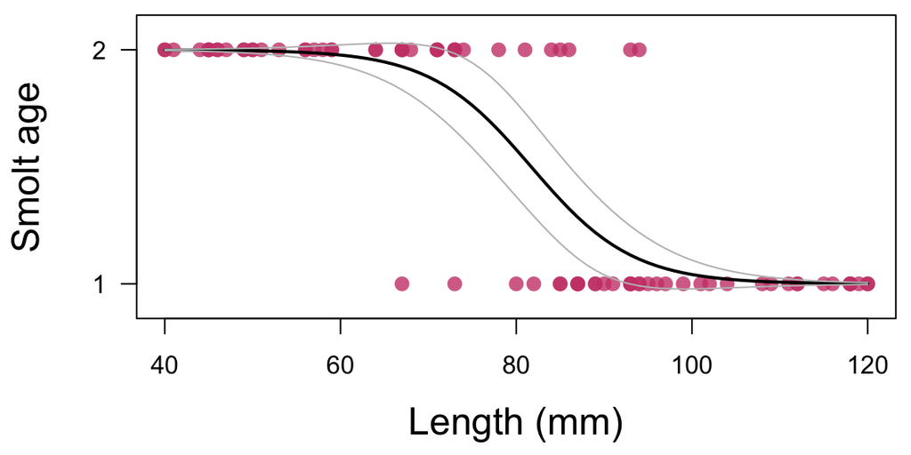

```r
## get the SE of the response
se_wrong <- predict(fit_mod, newdata, type = "response", se.fit = TRUE)$se.fit
## wrong upper 95% CI
wrong_up <- p_hat + 1.96*se_wrong
## wrong lower 95% CI
wrong_lo <- p_hat - 1.96*se_wrong

## set plot area
par(mai = c(0.9, 0.9, 0.1, 0.1),
    omi = c(0, 0, 0, 0),
    cex.lab = 1.5)

## plot age vs length
plot(ll, yy, pch = 16, cex = 1.3, col = clr, ylim = c(-0.1, 1.1),
     yaxt = "n", ylab = "Smolt age", xlab = "Length (mm)")
axis(2, at = c(0,1), labels = c(1,2), las = 1)
## add model fit
lines(sl, p_hat, lwd = 2)
## add wrong CI's
lines(sl, wrong_up, lwd = 1, col = "gray")
lines(sl, wrong_lo, lwd = 1, col = "gray")
```

Notice that the CI’s overlap 0 and 1, which necessarily violates our constraint that probability must lie between 0 and 1.

Now here’s how to estimate the CI’s properly.

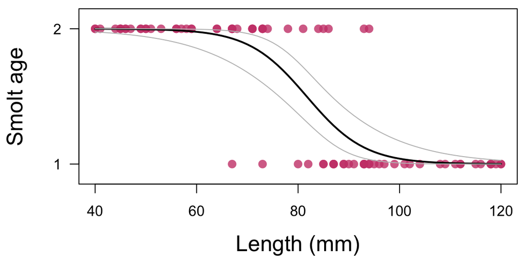

```r
## get the SE of the response
se_right <- predict(fit_mod, newdata, type = "link", se.fit = TRUE)$se.fit
## right upper 95% CI
right_up <- 1 / (1 + exp(-(eta + 1.96*se_right)))
## right lower 95% CI
right_lo <- 1 / (1 + exp(-(eta - 1.96*se_right)))

## set plot area
par(mai = c(0.9, 0.9, 0.1, 0.1),
    omi = c(0, 0, 0, 0),
    cex.lab = 1.5)

## plot age vs length
plot(ll, yy, pch = 16, cex = 1.3, col = clr, ylim = c(-0.1, 1.1),
     yaxt = "n", ylab = "Smolt age", xlab = "Length (mm)")
axis(2, at = c(0,1), labels = c(1,2), las = 1)
## add model fit
lines(sl, p_hat, lwd = 2)
## add right CI's
lines(sl, right_up, lwd = 1, col = "gray")
lines(sl, right_lo, lwd = 1, col = "gray")
```

#### Finding the probability of 0.5

Sometimes we would like to know at which level of the predictor variable do we expect an equal probability of obtaining a 0 or 1. In this case we can ask, “What is the length at which the probability of smolting at age-2 is 0.5?”

$$p_i = \frac{1}{1 + \exp(\text{-} \mathbf{X}_i \boldsymbol{\beta})} \\
\Downarrow \\
0.5 = \frac{1}{1 + \exp(\text{-}[14 - 0.17 L_{0.5}])} \\
\Downarrow \\
L_{0.5} \approx 82 ~ \text{mm}$$

#### Computing the odds

We have seen that we can express the results from a logistic regression in terms of the *odds*. The odds $o$ are an unbounded alternative to probability $p$, such that if the odds are $k$-to-1 against something, which we can write as $o = 1/k$, then

$$p = \frac{1}{1 + k} ~ \Rightarrow ~ k = \frac{1 - p}{p}$$

For example, if $k$ = 4, then $p = \frac{1}{1 + 4} = 0.2$. If $p$ = 0.8, then $k = \frac{1 - 0.8}{0.8} = \frac{1}{4}$.

In a logistic regression model, the logit function gives us the log odds, such that

$$\text{logit}(p) = \mathbf{X} \boldsymbol{\beta} \\
\Downarrow \\
\log \left( \frac{p}{1 - p} \right) = \mathbf{X} \boldsymbol{\beta} \\
\Downarrow \\
\log ( \text{odds} ) = \mathbf{X} \boldsymbol{\beta} \\
\Downarrow \\
\text{odds} = \exp (\mathbf{X} \boldsymbol{\beta})$$

### Inference

We have seen many ways to conduct inference on linear models. For GLMs, deviance $D$ is a goodness-of-fit statistic that is a generalization of using the sum-of-squares of residuals in ordinary least squares to cases where model-fitting is achieved by maximum likelihood. The deviance is defined as

$$D = \text{-}2 \log \mathcal{L}$$

We can use the deviance as part of a likelihood ratio test, such that

$$\lambda = \text{-}2 \log \frac{\mathcal{L}_A}{\mathcal{L}_B} \sim
\chi^2_{df = k_A - k_B} \\
\Downarrow \\
\lambda = \text{-}2 (\log \mathcal{L}_A - \log \mathcal{L}_B) \sim
\chi^2_{df = k_A - k_B} \\
\Downarrow \\
\lambda = D(B) - D(A) \sim \chi^2_{df = k_A - k_B}$$

The output from `glm()` includes the deviances for the full model and a null model with no predictors.

```r
## our fitted model
faraway::sumary(fit_mod)
```

```
##              Estimate Std. Error z value  Pr(>|z|)
## (Intercept) 14.216166   3.417816  4.1594 3.190e-05
## length      -0.173990   0.041051 -4.2383 2.252e-05
##
## n = 80 p = 2
## Deviance = 39.91950 Null Deviance = 110.70347 (Difference = 70.78396)
```

We can use a likelihood ratio test to evaluate the data support for the length predictor in our smolt model, where $H_0 : \beta_1 = 0$.

```r
## deviance of full model
D_full <- summary(fit_mod)$deviance
## deviance of null model
D_null <- summary(fit_mod)$null.deviance
## test statistic
lambda <- D_null - D_full
## LRT with df = 1
(p_value <- pchisq(lambda, 1, lower.tail = FALSE))
```

```
## [1] 3.985637e-17
```

This $p$-value is very small so we can reject $H_0$ and conclude that the effect of length is indeed non-zero.

#### Significance test for $\beta_i$

An alternative to the likelihood ratio test is a $z$ test, where

$$z = \frac{\hat{\beta_i}}{\text{SE}(\hat{\beta_i})} \sim z_{\alpha / 2}$$

The `summary()` output from a fitted GLM includes this the results of this test.

```r
## summary table
faraway::sumary(fit_mod)
```

```
##              Estimate Std. Error z value  Pr(>|z|)
## (Intercept) 14.216166   3.417816  4.1594 3.190e-05
## length      -0.173990   0.041051 -4.2383 2.252e-05
##
## n = 80 p = 2
## Deviance = 39.91950 Null Deviance = 110.70347 (Difference = 70.78396)
```

As you can see, the $p$-value for the $z$ test is also very small.

#### Confidence interval for $\beta_i$

We can also compute a 100(1 - $\alpha$)% confidence interval on the regression coefficient as

$$\hat{\beta_i} \pm z_{\alpha / 2} \text{SE}(\hat{\beta_i})$$

which we do in **R** via

```r
## beta
beta_1 <- coef(fit_mod)[2]
## SE of beta
se_beta_1 <- sqrt(diag(vcov(fit_mod)))[2]
## 95% CI
beta_1 + c(-1,1) * 1.96 * se_beta_1
```

```
## [1] -0.25445073 -0.09352909
```

We can also compute CI’s based on the profile likelihood with `confint()`

```r
## 95% CI via profile likelihood
confint(fit_mod)
```

```
##                 2.5 %     97.5 %
## (Intercept)  8.730190 22.4253100
## length      -0.272113 -0.1078227
```

Due to possible bias in $\text{SE}(\beta)$, however, we can also compute CI’s based on the *profile likelihood*, which we obtain by evaluating the likelihood along a sequence of possible parameter values.

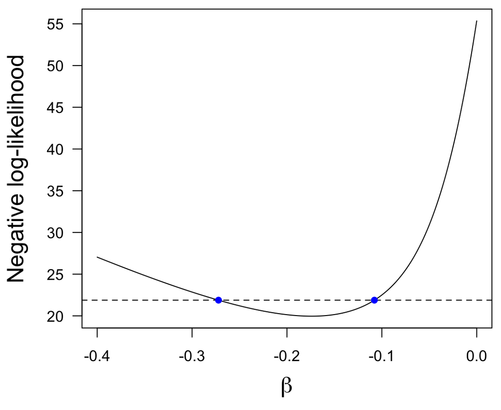

```r
## number of points to profile
nb <- 200
## possible beta's
beta_hat <- seq(-0.4, 0, length = nb)
## calculate neg-LL of possible beta's
pl <- rep(NA, nb)
for(i in 1:nb) {
  mm <- glm(age ~ 1 + offset(beta_hat[i] * length), data = df,
            family = binomial(link = "logit"))
  pl[i] <- -logLik(mm)
}

## set plot area
par(mai = c(0.9, 0.9, 0.1, 0.1),
    omi = c(0, 0, 0, 0),
    cex.lab = 1.5)

## plot likelihood profile
plot(beta_hat, pl, type = "l", las = 1,
     ylab = "Negative log-likelihood", xlab = expression(beta))
crit <- -(logLik(fit_mod) - qchisq(0.95, 1) / 2)
abline(h = crit, lty = "dashed")
points(confint(fit_mod)[2,], c(crit, crit), pch = 16, col = "blue")
```

#### Model selection via AIC

As with other linear models, we can use AIC to help select among possible models.

$$\begin{align}
AIC &= 2 k - 2 \log \mathcal{L} \\
&= 2 k + D
\end{align}$$

Here are three different ways to compute the AIC for our smolt age model.

```r
## AIC
AIC(fit_mod)
## AIC via likelihood
(2 * 2) - 2 * logLik(fit_mod)
## AIC via deviance
(2 * 2) + summary(fit_mod)$deviance
```

```
## [1] 43.9195
## 'log Lik.' 43.9195 (df=2)
## [1] 43.9195
```

We can compare our model with length as a predictor to a null model with no predictors via the following code.

```r
## fit null model
fit_null <- glm(age ~ 1, data = df,
                family = binomial(link = "logit"))
faraway::sumary(fit_null)
```

```
##             Estimate Std. Error z value Pr(>|z|)
## (Intercept)  0.10008    0.22389   0.447   0.6549
##
## n = 80 p = 1
## Deviance = 110.70347 Null Deviance = 110.70347 (Difference = 0.00000)
```

```r
## difference in AIC
AIC(fit_null) - AIC(fit_mod)
```

```
## [1] 68.78396
```

### Diagnostics

#### Residuals

As with other models, it’s important to examine diagnostic checks for our fitted models. One of the first things we can do is inspect the model residuals. We usually think about residuals $e$ as

$$e = y - \hat{y}$$

but with logistic regression, the response can take 1 of 2 possible values. Let’s plot them to see how they look.

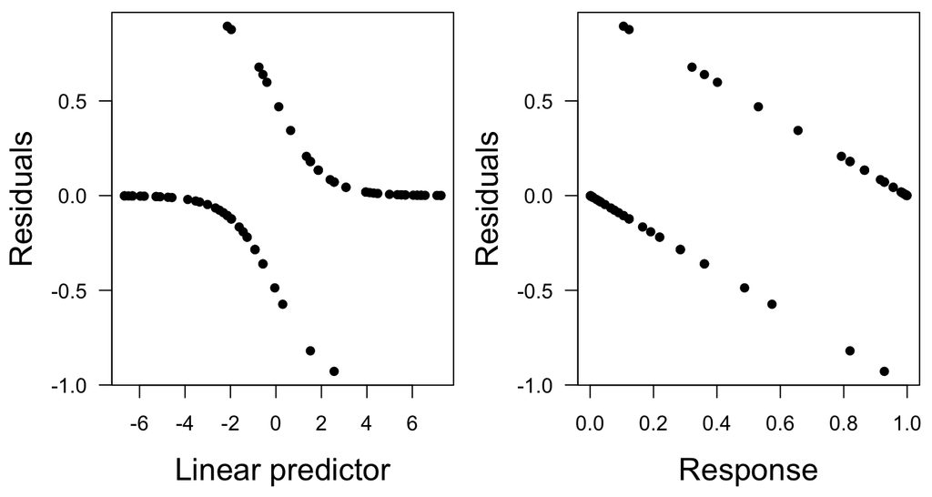

```r
## raw residuals
res_raw <- df$age - predict(fit_mod, type = "response")
## equivalently
res_raw <- residuals(fit_mod, type = "response")

## set plot area
par(mfrow = c(1, 2),
    mai = c(0.9, 0.9, 0.1, 0.1),
    omi = c(0, 0, 0, 0),
    cex.lab = 1.5)

## plot resids vs eta
plot(predict(fit_mod), res_raw, las = 1, pch = 16,
     ylab = "Residuals", xlab = "Linear predictor",
     main = "")
## plot resids vs response
plot(predict(fit_mod, type = "response"), res_raw, las = 1, pch = 16,
     ylab = "Residuals", xlab = "Response",
     main = "")
```

#### Deviance residuals

We can instead use the *deviance residuals*, which we define as

$$e_i = (2 y_i - 1) D_i$$

where $2 y - 1 = 1$ if y is 1, and $2 y - 1 = -1$ if y is 0. These are the default residuals returned by `residuals()`. We then place the deviance residuals into bins for easier inspection, noting that

- it’s sensitive to the number of bins (~30/bin is good)
- the mean of $e$ is not constrained to be 0
- ~95% of points should fall within the CI

We can use `binnedplot()` from the **arm** package to do this automatically for us.

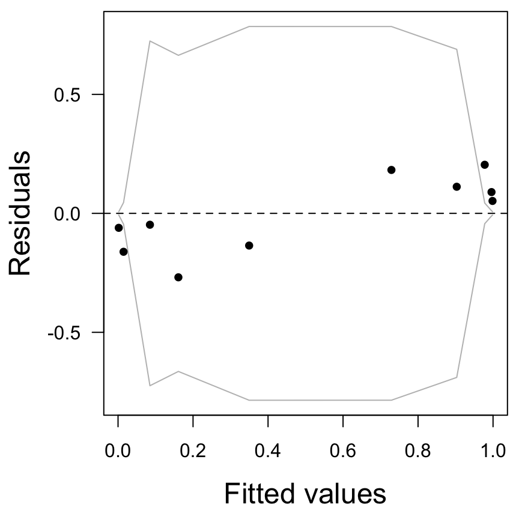

```r
library(arm)

## set plot area
par(mai = c(0.9, 0.9, 0.1, 0.1),
    omi = c(0, 0, 0, 0),
    cex.lab = 1.5)

## plot resids vs eta
binnedplot(fitted(fit_mod), residuals(fit_mod), las = 1, pch = 16,
     ylab = "Residuals", xlab = "Fitted values",
     main = "")
```

#### Leverage

We can also calculate the leverages $h$ to look for unusual observation in *predictor space*. Recall we are potentially concerned about any

$$h_i > 2 \frac{k}{n}$$

We can use `hatvalues()` to calculate the leverages and `faraway::halfnorm()` to plot them.

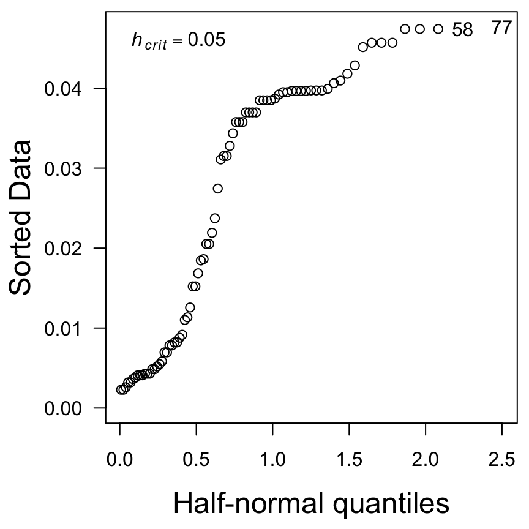

```r
## set plot area
par(mai = c(0.9, 0.9, 0.1, 0.1),
    omi = c(0, 0, 0, 0),
    cex.lab = 1.5)

## leverages
levs <- hatvalues(fit_mod)

## threshhold value
h_crit <- 2 * length(coef(fit_mod)) / nn

## halfnormal plot
faraway::halfnorm(levs, las = 1)
text(0, 0.92*par("usr")[4], substitute(italic(h[crit]) == h_crit, list(h_crit = h_crit)), pos = 4)
```

#### Cook’s Distance

Recall that we can also use Cook’s $D$ to identify potentially influential points. Cook’s $D$ is defined as

$$D_{i}=e_{i}^{2} \frac{1}{k}\left(\frac{h_{i}}{1-h_{i}}\right)$$

In general, we should be concerned about an $D_i > F^{(0.5)}_{n, n - k} \approx 1$. We can compute the $D_i$ with `cooks.distance()` and again use `faraway::halfnorm()` to plot them.

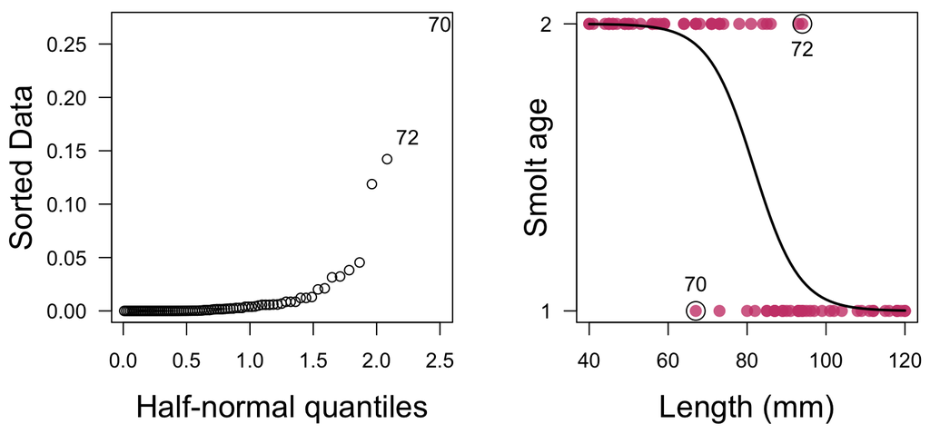

```r
## set plot area
par(mfrow = c(1, 2),
    mai = c(0.9, 0.9, 0.1, 0.1),
    omi = c(0, 0, 0, 0),
    cex.lab = 1.5)

## Cook's D
CD <- cooks.distance(fit_mod)

## halfnormal plot
faraway::halfnorm(CD, las = 1)

## plot age v
plot(ll, yy + 1, las = 1, pch = 16, cex = 1.3, col = clr,
     yaxt = "n", ylab = "", xlab = "Length (mm)")
lines(sl, p_hat + 1, lwd = 2)
points(df[70,"length"], df[70, "age"] + 1, pch = 1, cex = 2)
text(df[70,"length"], df[70, "age"] + 1, "70", pos = 3, offset = 0.8)
points(df[72,"length"], df[72, "age"] + 1, pch = 1, cex = 2)
text(df[72,"length"], df[72, "age"] + 1, "72", pos = 1, offset = 0.8)
mtext(side = 2, "Smolt age", line = 1, cex = 1.5)
axis(2, at = c(1,2), las = 1)
```

### Goodness of fit

Once we’ve fit a model, it’s natural to ask, “How well does our model fit the data?” One simple check is a $\chi^2$ test on the *standardized residuals*

$$e_i = \frac{y_i - \hat{y}_i}{\text{SD}(y_i)} = \frac{y_i -
\hat{y}_i}{\sqrt{(\hat{y}_i (1 - \hat{y}_i))}} \\
\Downarrow \\
\sum_{i = 1}^n e_i \sim \chi^2_{(n - k - 1)}$$

This is easy to do in **R**.

```r
## residuals
ee <- residuals(fit_mod, type = "response")
## fitted values
y_hat <- fitted(fit_mod)
## standardized residuals
rr <- ee / (y_hat * (1 - y_hat))
## test stat
x2 <- sum(rr)
## chi^2 test
pchisq(x2, nn - length(coef(fit_mod)) - 1, lower.tail = FALSE)
```

```
## [1] 1
```

The $p$-value is large so we detect no lack of fit

#### Binned predictions

It’s hard to compare our predictions on the real interval [0,1] to discrete binary outcomes that take a value of 0 or 1. To help, we can compute $\hat{y}$ for *bins of data*. Here are the smolt age data split into 8 equal sized bins along the length predictor.

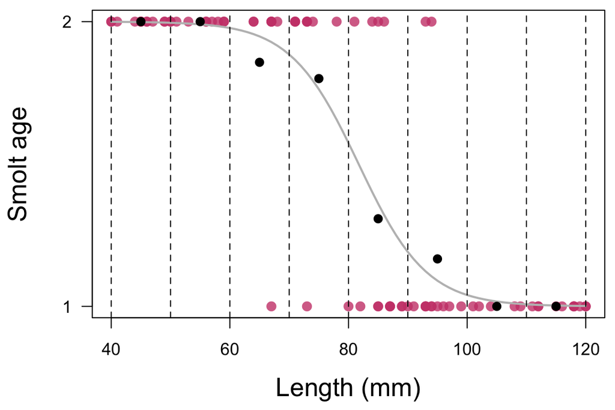

```r
## cut data
l_cut <- cut(df$length, seq(40, 120, 10))
y_bin <- by(df$age, l_cut, mean)
y_cut <- cut(fitted(fit_mod), quantile(fitted(fit_mod), probs = seq(0, 1, 1/8)))
p_bin <- by(fitted(fit_mod), y_cut, mean)

## set plot area
par(mai = c(0.9, 0.9, 0.1, 0.1),
    omi = c(0, 0, 0, 0),
    cex.lab = 1.5)
## plot age v
plot(ll, yy + 1, las = 1, pch = 16, cex = 1.3, col = clr,
     yaxt = "n", ylab = "Smolt age", xlab = "Length (mm)")
lines(seq(40, 120), p_hat + 1, lwd = 2, col = "gray")
points(seq(45, 115, 10), y_bin + 1, pch = 16, cex = 1.2)
abline(v = c(seq(40, 120, 10)), lty = "dashed")
axis(2, at = c(1,2), las = 1)
```

The black points are the estimated proportion of smolts, which seem to agree rather well with the model fit (gray line). We can now compare them to one another.

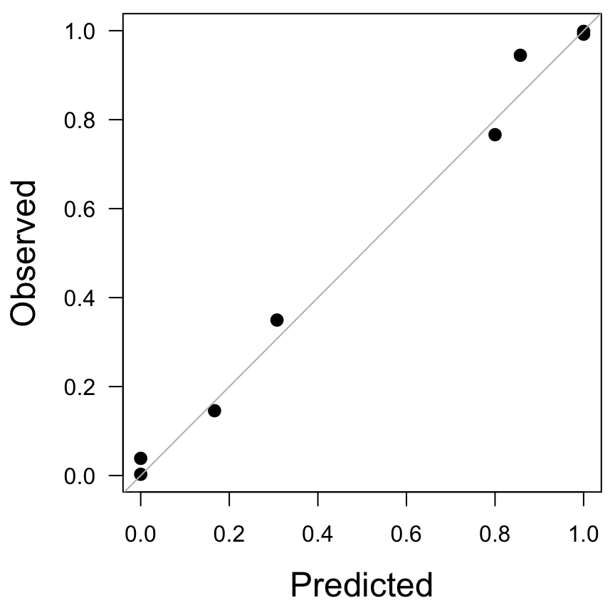

```r
## set plot area
par(mai = c(0.9, 0.9, 0.1, 0.1),
    omi = c(0, 0, 0, 0),
    cex.lab = 1.5)
## plot age v
plot(y_bin, rev(p_bin), las = 1, pch = 16, cex = 1.3,
     ylab = "Observed", xlab = "Predicted")
abline(a = 0, b = 1, col = "gray")
```

#### Hosmer-Lemeshow test

We can formalize this binned comparison with the Hosmer-Lemeshow test, which is given by

$$HL = \sum_{j = 1}^J \frac{(y_j - m_j \hat{p}_J)^2}{m_j \hat{p}_J(1 -
\hat{p}_J)} \sim \chi^2_{(J - 1)}$$

where $J$ is the number of groups and $y_j = \sum y_{i = j}$. We can perform the Hosmer-Lemeshow test with `generalhoslem::logitgof()`. The null hypothesis is the model fits the data well.

```r
## H-L test with 8 groups
generalhoslem::logitgof(obs = df$age, exp = fitted(fit_mod), g = 8)
```

```
##
##  Hosmer and Lemeshow test (binary model)
##
## data:  df$age, fitted(fit_mod)
## X-squared = 1.35, df = 6, p-value = 0.9688
```

The $p$-value is large so we conclude an adequate fit.

#### Proportion of variance explained

Calculating $R^2$ for logistic models is not the same as linear models. Given the deviance $D_M$ for our model and a null model $D_0$, we define

$$R^2 = \frac{1 - \exp \left( [D_M - D_0]/n \right)}{1 - \exp(\text{-}D_0
/ n)}$$

Here is the $R^2$ for our smolt-at-age model.

```r
## deviances
DM <- fit_mod$deviance
D0 <- fit_mod$null.deviance
# R^2
R2 <- (1 - exp((DM - D0) / nn)) / (1 - exp(-D0 / nn))
round(R2, 2)
```

```
## [1] 0.78
```

# Overdispersion

If our model fits the data well, we expect the deviance $D$ to be $\chi^2$ distributed, but sometimes the deviance is larger than expected. There are several things that can lead to this so-called *overdispersion*:

- model mis-specification
- outliers
- non-linear relationship between $x$ and $\eta$
- non-independence in the observed data

## Elk in clear cuts

Let’s return to the example we saw in lecture concerning elk use of clear cuts for browsing where the probability of finding elk generally decreases with height of underbrush. We consider data from an observational study designed to estimate the probability of finding elk as a function of underbrush height. Specifically, the study involved

- 29 forest sections that were sampled for elk pellets along line transects
- estimates of the mean height of underbrush for each section
- recordings of the presence or absence of pellets at 9-13 points per transect

Here are the data.

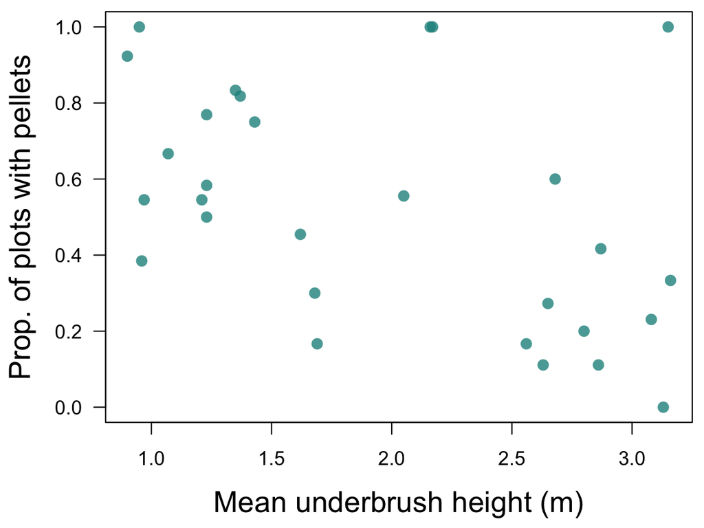

```r
set.seed(514)
## sample size
nn <- 29
## intercept
b0 <- 2
## slope
b1 <- -1
## VIF
vif <- 3
## heights
sl <- seq(90, 330)/100
hh <- sample(sl, nn, replace = TRUE)
## plots per forest section
ll <- sample(seq(9, 13), nn, replace = TRUE)
## probability as function of height
pp <- 1 / (1 + exp(-(b0 + b1*hh)))
## sim smolt age {0,1}
yy <- rep(NA, nn)
for(i in 1:nn) {
  yy[i] <- rmutil::rbetabinom(1, ll[i], pp[i], vif)
#  yy[i] <- rbinom(1, ll[i], pp[i])
}

## make data frame for model fitting
df <- data.frame(veg_height = hh, plots = ll, pellets = yy)

clr <- viridis::viridis(1, 0.8, 0.5, 0.5)
## set plot area
par(mai = c(0.9, 0.9, 0.1, 0.1),
    omi = c(0, 0, 0, 0),
    cex.lab = 1.5)
## plot age v
plot(hh, yy/ll, las = 1, pch = 16, cex = 1.3, col = clr,
     ylab = "Prop. of plots with pellets", xlab = "Mean underbrush height (m)")
```

## Binomial model

For these data, we’ll use a logistic regression model based on the proportions of plots where elk pellets were found. Here, $y_i$ is the number of pellets recorded in transect $i$, $N_i$ is the total number of plots along transect $i$, $p_i$ is the probability of finding elk pellets, and $H_i$ is the mean height of underbrush in forest section $i$. Let’s specify the following three components for our GLM.

$$\begin{aligned}
\text{data distribution:} & ~~ y_i \sim \text{Binomial}(N_i, p_i) \\
\\
\text{link function:} & ~~ \text{logit}(p_i) =
\text{log}\left(\frac{p_i}{1-p_i}\right) = \eta_i \\ \\
\text{linear predictor:} & ~~ \eta_i = \alpha + \beta H_i
\end{aligned}$$

### Variance inflation factor

Recall that the variance for a binomial of size $n$ is given by

$$\text{Var}(y) = n p (1 - p)$$

If $\text{Var}(y) > n p (1 - p)$ then we have overdispersion. To address overdispersion, we can include the *dispersion* parameter (or “variance inflation factor”) $c$, such that

$$\text{Var}(y) = c n p (1 - p)$$

We can estimate $c$ from the deviance $D$ as

$$\hat{c} = \frac{D}{n - k}$$

### Pearson’s $\chi^2$ statistic

Sometimes the deviance is biased, however, so we can turn to Pearson’s $\chi^2$ statistic is similar to the deviance

$$X^2 = \sum_{i = 1}^n \frac{(O_i - E_i)^2}{E_i} \sim \chi^2_{(n - 1)}$$

where $O_i$ is the observed count and $E_i$ is the expected count. For a binomial distribution, we have

$$X^2 = \sum_{i = 1}^n \frac{(O_i - E_i)^2}{E_i} \\
\Downarrow \\
X^2 = \sum_{i = 1}^n \frac{(y_i - n_i \hat{p}_i)^2}{n_i \hat{p}_i}$$

We can then estimate $c$ as

$$\hat{c} = \frac{X^2}{n - k}$$

### An overdispersed model

Let’s fit our GLM to the elk data and compare the results with and without the assumption that $\hat{c}$ = 1.

```r
## fit model with glm
elk_mod <- glm(cbind(pellets, plots - pellets) ~ veg_height, data = df,
               family = binomial(link = "logit"))
## original fit
faraway::sumary(elk_mod)
```

```
##             Estimate Std. Error z value  Pr(>|z|)
## (Intercept)  1.61718    0.31737  5.0955 3.477e-07
## veg_height  -0.76954    0.15121 -5.0891 3.598e-07
##
## n = 29 p = 2
## Deviance = 119.08081 Null Deviance = 146.68980 (Difference = 27.60898)
```

```r
## overdispersion parameter
c_hat <- deviance(elk_mod) / (nn - 2)
## re-scaled estimates
faraway::sumary(elk_mod, dispersion = c_hat)
```

```
##             Estimate Std. Error z value Pr(>|z|)
## (Intercept)  1.61718    0.66651  2.4263  0.01525
## veg_height  -0.76954    0.31756 -2.4233  0.01538
##
## Dispersion parameter = 4.41040
## n = 29 p = 2
## Deviance = 119.08081 Null Deviance = 146.68980 (Difference = 27.60898)
```

Notice how the standard errors of the parameters have increased, which means the $z$ values decrease and their corresponding $p$-values increased.

### Quasi-AIC

For binomial models with overdispersion, we can modify the regular equation for AIC

$$AIC = 2 k - 2 \log \mathcal{L}$$

to be a *quasi*-AIC

$$QAIC = 2 k - 2 \frac{\log \mathcal{L}}{\hat{c}}$$

Here is a comparison of the results of our elk model to a model with only an intercept using both forms of AIC.

```r
## fit null
elk_null <- glm(cbind(pellets, plots - pellets) ~ 1, data = df,
                family = binomial(link = "logit"))

## model selection results
tbl_mods <- matrix(NA, 2, 6)
rownames(tbl_mods) <- c("intercept + slope  ", "intercept only  ")
colnames(tbl_mods) <- c("k", "neg-LL", "AIC", "deltaAIC", "QAIC", "deltaQAIC")
tbl_mods[,1] <- c(2,1)
tbl_mods[,2] <- round(-c(logLik(elk_mod), logLik(elk_null)), 1)
tbl_mods[,3] <- round(c(AIC(elk_mod), AIC(elk_null)), 1)
tbl_mods[,4] <- round(tbl_mods[,3] - min(tbl_mods[,3]), 1)
tbl_mods[,5] <- round(2 * tbl_mods[,1] + 2 * tbl_mods[,2] / c_hat, 1)
tbl_mods[,6] <- round(tbl_mods[,5] - min(tbl_mods[,5]), 1)
tbl_mods
```

```
##                     k neg-LL   AIC deltaAIC QAIC deltaQAIC
## intercept + slope   2   90.7 185.4      0.0 45.1       0.0
## intercept only      1  104.5 211.0     25.6 49.4       4.3
```

### Quasi-binomial models

When the data are overdispersed, we can relate the mean and variance of the response to the linear predictor *without* any additional information about the binomial distribution. However, this creates problems when we want to make inference via hypothesis tests or CI’s. Without a formal distribution for the data, we can use a *quasi-likelihood*.

We can fit a quasi-binomial with `glm()` by specifying `family = quasibinomial(link = "logit")`

```r
## quasi-binomial
elk_quasi <- glm(cbind(pellets, plots - pellets) ~ veg_height, data = df,
                 family = quasibinomial(link = "logit"))
```

and compare these results to those from above based on estimating the overdispersion parameter and using it for inference.

```r
## variance inflation
faraway::sumary(elk_mod, dispersion = c_hat)
```

```
##             Estimate Std. Error z value Pr(>|z|)
## (Intercept)  1.61718    0.66651  2.4263  0.01525
## veg_height  -0.76954    0.31756 -2.4233  0.01538
##
## Dispersion parameter = 4.41040
## n = 29 p = 2
## Deviance = 119.08081 Null Deviance = 146.68980 (Difference = 27.60898)
```

```r
## quasi-binomial
faraway::sumary(elk_quasi)
```

```
##             Estimate Std. Error t value Pr(>|t|)
## (Intercept)  1.61718    0.60978  2.6521  0.01323
## veg_height  -0.76954    0.29053 -2.6487  0.01333
##
## Dispersion parameter = 3.69153
## n = 29 p = 2
## Deviance = 119.08081 Null Deviance = 146.68980 (Difference = 27.60898)
```

These results are quite similar to one another.

### Beta-binomial models

Another option for binomial data is the beta distribution

$$f(y ; \mu, \phi)=\frac{\Gamma(\phi)}{\Gamma(\mu \phi) \Gamma((1-\mu)
\phi)} y^{\mu \phi-1}(1-y)^{(1-\mu) \phi-1}$$

with

$$\text{mean}(y) = \mu \\
\text{Var}(y) = \frac{\mu(1 - \mu)}{1 + \phi}$$

We can use `gam()` from the **mgcv** package to fit beta-binomial models.

```r
## load mgcv
library(mgcv)
## `gam()` needs proportions for the response
df$prop <- df$pellets / df$plots
## weight by num of plots per section
wts <- df$plots / mean(df$plots)
## fit model
elk_betabin <- gam(prop ~ veg_height, weights = wts, data = df,
                   family = betar(link = "logit"))
```

Let’s compare these estimates to those from our two models above.

```r
## beta-binomial
summary(elk_betabin)
```

```
##
## Family: Beta regression(0.349)
## Link function: logit
##
## Formula:
## prop ~ veg_height
##
## Parametric coefficients:
##             Estimate Std. Error z value Pr(>|z|)
## (Intercept)   1.1392     0.6559   1.737   0.0824 .
## veg_height   -0.3456     0.3187  -1.085   0.2781
## ---
## Signif. codes:  0 '***' 0.001 '**' 0.01 '*' 0.05 '.' 0.1 ' ' 1
##
##
## R-sq.(adj) =  0.128   Deviance explained = -1.69%
## -REML = -99.423  Scale est. = 1         n = 29
```

```r
## variance inflation
faraway::sumary(elk_mod, dispersion = c_hat)
```

```
##             Estimate Std. Error z value Pr(>|z|)
## (Intercept)  1.61718    0.66651  2.4263  0.01525
## veg_height  -0.76954    0.31756 -2.4233  0.01538
##
## Dispersion parameter = 4.41040
## n = 29 p = 2
## Deviance = 119.08081 Null Deviance = 146.68980 (Difference = 27.60898)
```

```r
## quasi-binomial
faraway::sumary(elk_quasi)
```

```
##             Estimate Std. Error t value Pr(>|t|)
## (Intercept)  1.61718    0.60978  2.6521  0.01323
## veg_height  -0.76954    0.29053 -2.6487  0.01333
##
## Dispersion parameter = 3.69153
## n = 29 p = 2
## Deviance = 119.08081 Null Deviance = 146.68980 (Difference = 27.60898)
```